# Rossmann Store Sales Prediction

Krishna Prasad

25 July 2016

## List of available datasets

- store.csv
- train.csv
- test.csv
- sample_submission

## Understanding of the variables in the datasets

```r
store <- read.csv("store.csv", header = TRUE, sep=",")
names(store)
```

```
##  [1] "Store"                     "StoreType"
##  [3] "Assortment"                "CompetitionDistance"
##  [5] "CompetitionOpenSinceMonth" "CompetitionOpenSinceYear"
##  [7] "Promo2"                    "Promo2SinceWeek"
##  [9] "Promo2SinceYear"           "PromoInterval"
```

```r
nrow(store)
```

```
## [1] 1115
```

```r
ncol(store)
```

```
## [1] 10
```

```r
summary(store)
```

```
##      Store        StoreType Assortment CompetitionDistance
##  Min.   :   1.0   a:602     a:593      Min.   :   20.0
##  1st Qu.: 279.5   b: 17     b:  9      1st Qu.:  717.5
##  Median : 558.0   c:148     c:513      Median : 2325.0
##  Mean   : 558.0   d:348                Mean   : 5404.9
##  3rd Qu.: 836.5                        3rd Qu.: 6882.5
##  Max.   :1115.0                        Max.   :75860.0
##                                        NA's   :3
##  CompetitionOpenSinceMonth CompetitionOpenSinceYear     Promo2
##  Min.   : 1.000            Min.   :1900             Min.   :0.0000
##  1st Qu.: 4.000            1st Qu.:2006             1st Qu.:0.0000
##  Median : 8.000            Median :2010             Median :1.0000
##  Mean   : 7.225            Mean   :2009             Mean   :0.5121
##  3rd Qu.:10.000            3rd Qu.:2013             3rd Qu.:1.0000
##  Max.   :12.000            Max.   :2015             Max.   :1.0000
##  NA's   :354               NA's   :354
##  Promo2SinceWeek Promo2SinceYear          PromoInterval
##  Min.   : 1.0    Min.   :2009                    :544
##  1st Qu.:13.0    1st Qu.:2011    Feb,May,Aug,Nov :130
##  Median :22.0    Median :2012    Jan,Apr,Jul,Oct :335
##  Mean   :23.6    Mean   :2012    Mar,Jun,Sept,Dec:106
##  3rd Qu.:37.0    3rd Qu.:2013
##  Max.   :50.0    Max.   :2015
##  NA's   :544     NA's   :544
```

#### Dataset: store.csv and variables possible values

- **Store**: A unique integer id for each store, total number of store `1115`
- **StoreType**: Possible values: `a:602, b:17, c:148, d:348`. Store models, *categorical values*
- **Assortment**: Describes an assortment level: a = basic, b = extra, c = extended, *categorical values*
- **CompetitionDistance**: Distance in meters to the nearest competitor store, it has missing data
- **CompetitionOpenSinceMonth**: Gives the approximate months of the time the nearest competitor was opened, possible value 1(JAN) to 12(DEC), *it has missin values*
- **CompetitionOpenSinceYear**: Gives the year of the time the nearest competitor was opened, possible value `Year` *it has missin values*
- **Promo2**: Indicates whether a store is running a promo on that day, possible values *TRUE* or *FALSE*
- **Promo2SinceWeek/Year**: Promo2Since[Year/Week] - describes the year and calendar week when the store started participating in Promo2
- **PromoInterval**: Describes the consecutive intervals Promo2 is started, naming the months the promotion is started anew. E.g. “Feb,May,Aug,Nov” means each round starts in February, May, August, November of any given year for that store

From simple intuitive say that Promo2, Promo2SinceWeek/Year, PromoInterval, competitir distance from store and start month-year, store type and store Assortment has influence on the sales, we will check compare which one has higher influence over sales by merging the store date with training dataset and finding the **covarience** with sales figure and by exploratory analysis with categorical varaible.

#### Dataset: train.csv and variables possible values

Let’s first check the varaibles in training dataset:

```r
train <- read.csv("train.csv", header = TRUE, sep=",")
names(train)
```

```
## [1] "Store"         "DayOfWeek"     "Date"          "Sales"
## [5] "Customers"     "Open"          "Promo"         "StateHoliday"
## [9] "SchoolHoliday"
```

```r
nrow(train)
```

```
## [1] 1017209
```

```r
ncol(train)
```

```
## [1] 9
```

```r
summary(train)
```

```
##      Store          DayOfWeek           Date             Sales
##  Min.   :   1.0   Min.   :1.000   01/01/14:   1115   Min.   :    0
##  1st Qu.: 280.0   1st Qu.:2.000   01/01/15:   1115   1st Qu.: 3727
##  Median : 558.0   Median :4.000   01/02/13:   1115   Median : 5744
##  Mean   : 558.4   Mean   :3.998   01/02/14:   1115   Mean   : 5774
##  3rd Qu.: 838.0   3rd Qu.:6.000   01/02/15:   1115   3rd Qu.: 7856
##  Max.   :1115.0   Max.   :7.000   01/03/13:   1115   Max.   :41551
##                                   (Other) :1010519
##    Customers           Open            Promo        StateHoliday
##  Min.   :   0.0   Min.   :0.0000   Min.   :0.0000   0:986159
##  1st Qu.: 405.0   1st Qu.:1.0000   1st Qu.:0.0000   a: 20260
##  Median : 609.0   Median :1.0000   Median :0.0000   b:  6690
##  Mean   : 633.1   Mean   :0.8301   Mean   :0.3815   c:  4100
##  3rd Qu.: 837.0   3rd Qu.:1.0000   3rd Qu.:1.0000
##  Max.   :7388.0   Max.   :1.0000   Max.   :1.0000
##
##  SchoolHoliday
##  Min.   :0.0000
##  1st Qu.:0.0000
##  Median :0.0000
##  Mean   :0.1786
##  3rd Qu.:0.0000
##  Max.   :1.0000
##
```

- **Store**: Store ID as mentioned above.
- **DayOfWeek**: Monday => 1 and Sunday => 7.
- **Date**: Store open date.
- **Sales**: Total turnover of the given day (Prediction variable)
- **Customers**: Total number of customer
- **Open**: Shop is open or not, 0 = closed, 1 = open
- **Promo**: Is any promotion running or not, 0 = no promo, 1 = promo
- **StateHoliday**: Indicates a state holiday, a = public holiday, b = Easter holiday, c = Christmas, 0 = None
- **SchoolHoliday**: Indicates public schools close or not, 1 = school holiday, 0 = not school holiday

#### Dataset: test.csv and variables possible values

Let’s first check the varaibles in training dataset:

```r
test <- read.csv("test.csv")
names(test)
```

```
## [1] "Id"            "Store"         "DayOfWeek"     "Date"
## [5] "Open"          "Promo"         "StateHoliday"  "SchoolHoliday"
```

- **Id**: Serial number of test cases
- **Store**: Store id as discussed above
- **DayOfWeek**: As discuss above
- **Date**: Store open date.
- **Open**: Shop is open or not, 0 = closed, 1 = open
- **Promo**: Is any promotion running or not, 0 = no promo, 1 = promo
- **StateHoliday**: Indicates a state holiday, a = public holiday, b = Easter holiday, c = Christmas, 0 = None
- **SchoolHoliday**: Indicates public schools close or not, 1 = school holiday, 0 = not school holiday

##### **Customers** records are not in test data set, which indicate that this should not be considered as feature in model.

## Feature Selection

- **Customers** records are not in test data set, which indicate that this should not be considered as feature in model.
- **DayOfWeek** Let’s plot the averge Sales on each days, Mon(1) to Sun(7)

```r
library(dplyr)
```

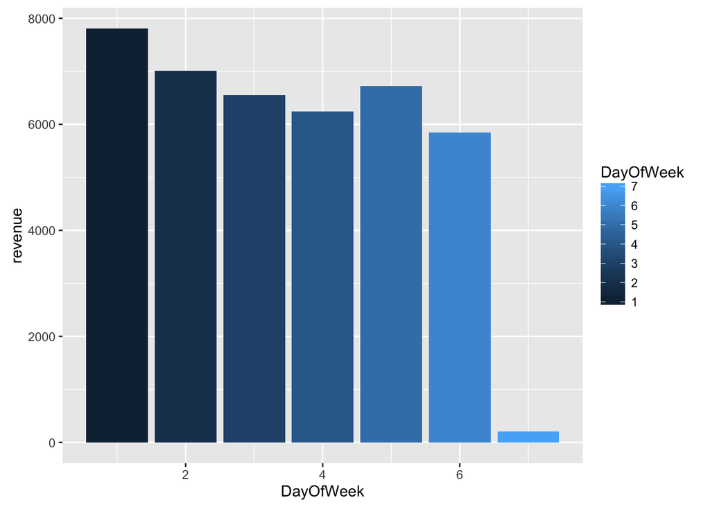

```r
library(ggplot2)
AvgRev_by_DayOfWeek <- train %>% group_by(DayOfWeek) %>% summarise(revenue = sum(as.numeric(Sales))/n())
g <- ggplot(data = AvgRev_by_DayOfWeek, aes(x= DayOfWeek, y = revenue, fill = DayOfWeek))
g <- g + geom_bar(stat="identity")
plot(g)
```

```r
rm(g)
```

So the `DayOfWeek` columns can taken as feature by three ways: * it can be bucket into three group: Monday(which has heighest Sales value) => Mon, Tuesday to Saturday => TWTFS, Sunday => Sun. * it can be bucket into four group: Monday => Mon, Tue .. Friday => TWTF, Saturday => Sat & Sunday. Will train model for both and check the accuracy

- **Date**: Now let’s check that the months, years are also influrenace the sales values or not

```r
library(dplyr)
library(ggplot2)
months <- strftime(train$Date, '%b')
months[1:3]
```

```
## [1] "Jul" "Jul" "Jul"
```

```r
train <- data.frame(train, months)
head(train)
```

```
##   Store DayOfWeek     Date Sales Customers Open Promo StateHoliday
## 1     1         5 31/07/15  5263       555    1     1            0
## 2     2         5 31/07/15  6064       625    1     1            0
## 3     3         5 31/07/15  8314       821    1     1            0
## 4     4         5 31/07/15 13995      1498    1     1            0
## 5     5         5 31/07/15  4822       559    1     1            0
## 6     6         5 31/07/15  5651       589    1     1            0
##   SchoolHoliday months
## 1             1    Jul
## 2             1    Jul
## 3             1    Jul
## 4             1    Jul
## 5             1    Jul
## 6             1    Jul
```

```r
# Group by month and find the Average Sales
Avg_Rev_Months <- train %>% group_by(months) %>% summarise(AvgRev = sum(as.numeric(Sales))/n())
Avg_Rev_Months
```

```
## Source: local data frame [12 x 2]
##
##    months   AvgRev
##    (fctr)    (dbl)
## 1     Apr 5738.867
## 2     Aug 5693.017
## 3     Dec 6826.611
## 4     Feb 5645.253
## 5     Jan 5465.396
## 6     Jul 6064.916
## 7     Jun 5760.964
## 8     Mar 5784.579
## 9     May 5489.640
## 10    Nov 6008.112
## 11    Oct 5537.037
## 12    Sep 5570.246
```

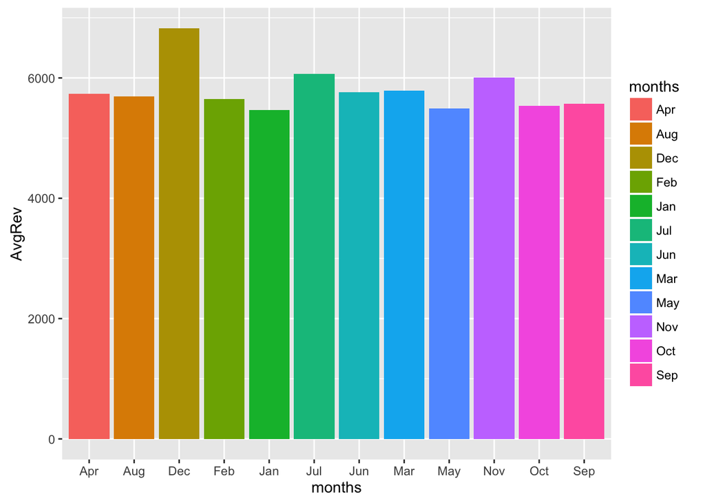

```r
g <- ggplot(data = Avg_Rev_Months, aes(x=months, y = AvgRev, fill = months))
g <- g + geom_bar(stat = "identity")
plot(g)
```

```r
rm(g)
rm(Avg_Rev_Months)
```

so the month can also be combine or without combination can be use as feature vector. If we combine then Dec - can be goes into single bucket, Jul & Nov goes to another bucket and remain on the other bucket as per the above bar graph.

Let’s check with year sales plot the graph

```r
train$Date <- as.Date(train$Date, "%d/%m/%y")
years <- strftime(train$Date, '%Y')
years[1:2]
```

```
## [1] "2015" "2015"
```

```r
train <- data.frame(train, years)
head(train)
```

```
##   Store DayOfWeek       Date Sales Customers Open Promo StateHoliday
## 1     1         5 2015-07-31  5263       555    1     1            0
## 2     2         5 2015-07-31  6064       625    1     1            0
## 3     3         5 2015-07-31  8314       821    1     1            0
## 4     4         5 2015-07-31 13995      1498    1     1            0
## 5     5         5 2015-07-31  4822       559    1     1            0
## 6     6         5 2015-07-31  5651       589    1     1            0
##   SchoolHoliday months years
## 1             1    Jul  2015
## 2             1    Jul  2015
## 3             1    Jul  2015
## 4             1    Jul  2015
## 5             1    Jul  2015
## 6             1    Jul  2015
```

```r
Avg_Rev_year <- train %>% group_by(years) %>% summarise(AvgRev = as.numeric(sum(as.numeric(Sales))/n()))
Avg_Rev_year
```

```
## Source: local data frame [3 x 2]
##
##    years   AvgRev
##   (fctr)    (dbl)
## 1   2013 5658.534
## 2   2014 5833.291
## 3   2015 5878.245
```

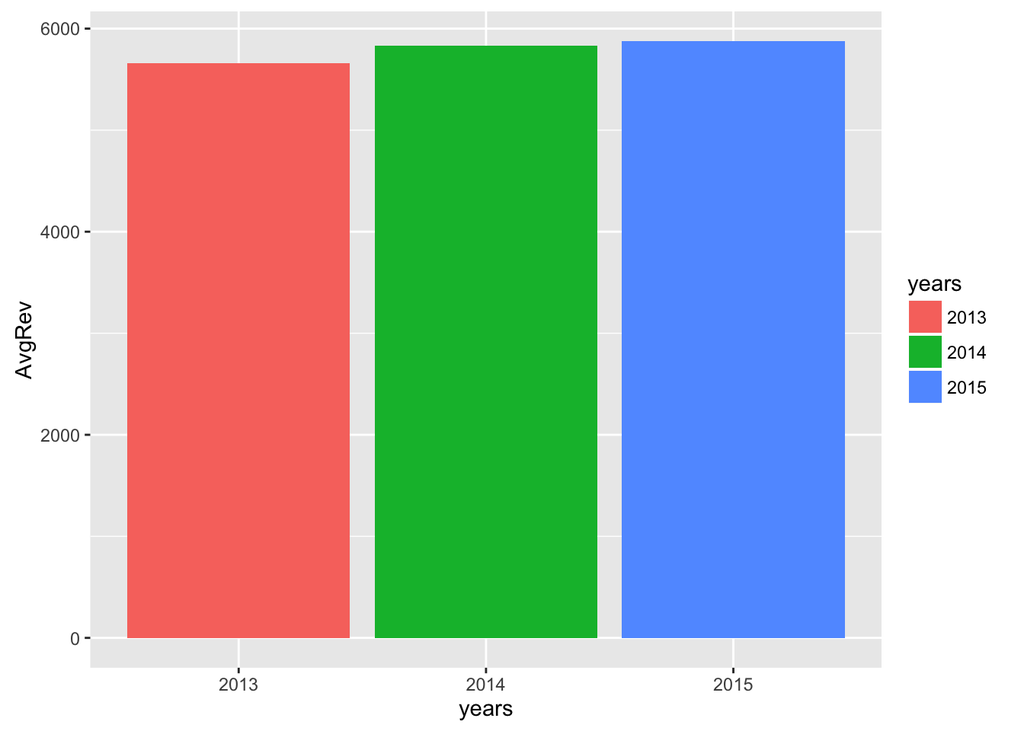

```r
g <- ggplot(data = Avg_Rev_year, aes(x=years, y = AvgRev, fill = years))
g <- g + geom_bar(stat = "identity")
plot(g)
```

```r
rm(g)
rm(Avg_Rev_year)
```

So years can also be treated as feature vectors.

- **Open**: Its straightforward that open is feature vector in the Sales but not meet the condition of IID since if the shop is close then Sales = 0 always, it can also be shown by graph, This feature vector can be droped before model training and if any records found in test data set then we will predict the Sales value 0.

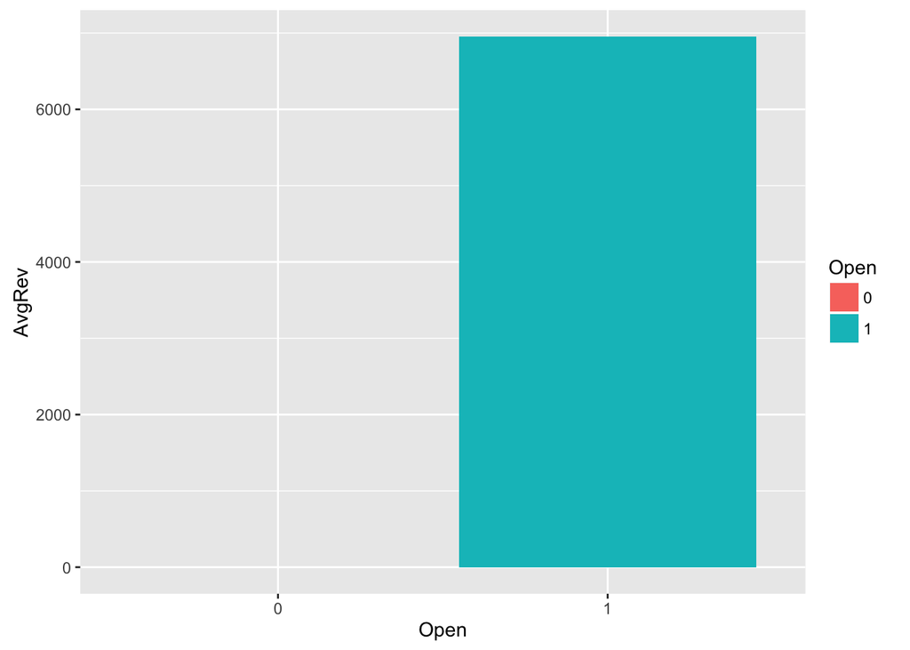

```r
library(dplyr)
library(ggplot2)
Sales_open <- train %>% group_by(Open) %>% summarise(AvgRev = as.numeric(sum(as.numeric(Sales)))/ n())
Sales_open$Open <- factor(Sales_open$Open)
g <- ggplot(data = Sales_open, aes(x= Open, y = AvgRev, fill = Open)) + geom_bar(stat = "identity")
plot(g)
```

```r
rm(g)
rm(Sales_open)
```

- **Promo**: Let’s see the effect of promotion on Sales

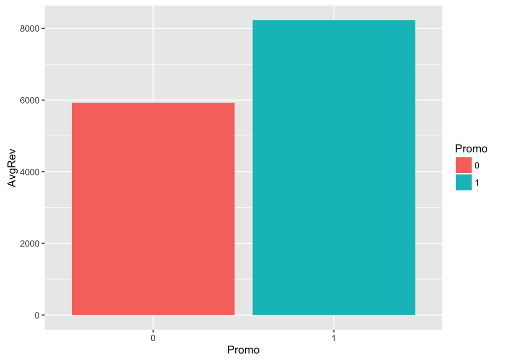

```r
library(dplyr)
library(ggplot2)
train = subset(train, train$Open == 1)
Sales_Promo <- train %>% group_by(Promo) %>% summarise(AvgRev = as.numeric(sum(as.numeric(Sales)))/n())
Sales_Promo$Promo <- factor(Sales_Promo$Promo)
g <- ggplot(data = Sales_Promo, aes(x = Promo, y= AvgRev, fill = Promo))
g <- g + geom_bar(stat = "identity")
plot(g)
```

```r
rm(g)
rm(Sales_Promo)
```

Let’s see the correlation of Sales with Promo 0.3681453, it says that Promo is correlated to Sales figure.

- **StateHoliday**:

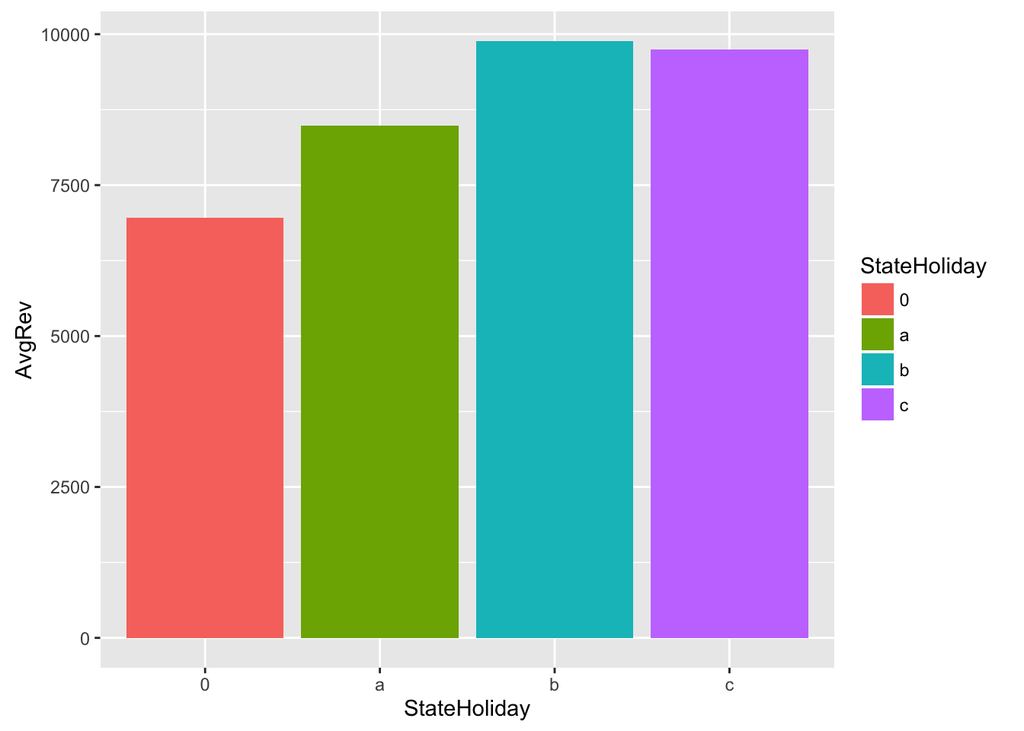

```r
library(dplyr)
library(ggplot2)
# Removed the close data first
train = subset(train, train$Open == 1)
Sales_Stateholiday <- train %>% group_by(StateHoliday) %>% summarise(AvgRev = as.numeric(sum(as.numeric(Sales)))/n())
Sales_Stateholiday$StateHoliday <- factor(Sales_Stateholiday$StateHoliday)
g <- ggplot(data = Sales_Stateholiday, aes(x = StateHoliday, y = AvgRev, fill = StateHoliday)) + geom_bar(stat = "identity")
plot(g)
```

- **SchoolHoliday**:

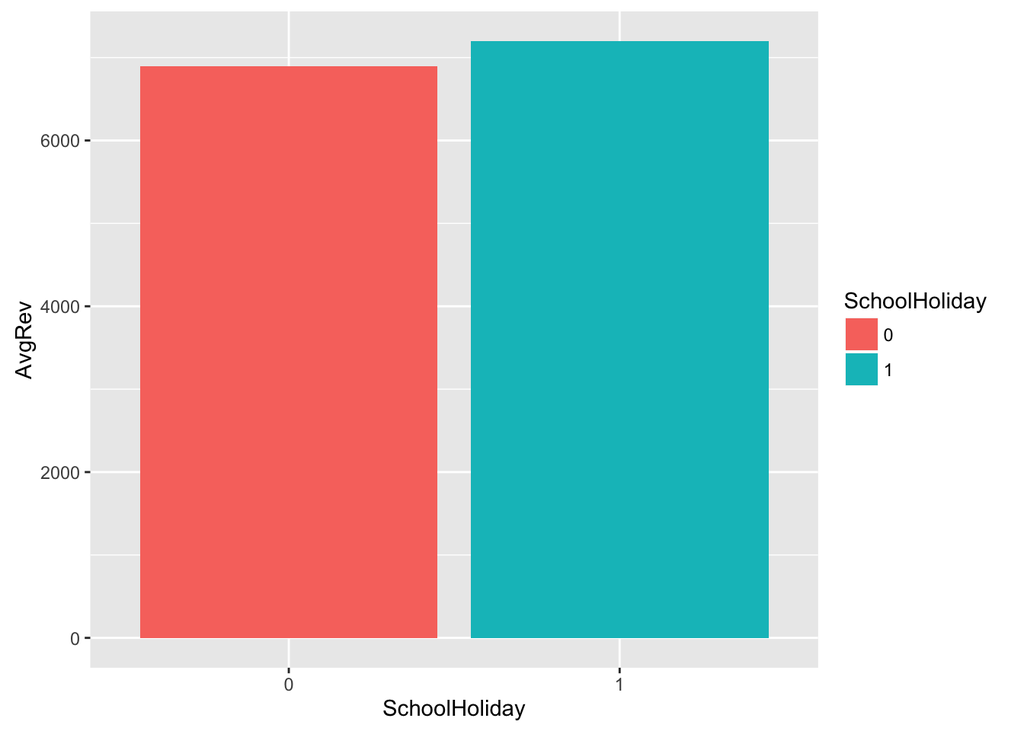

```r
library(dplyr)
library(ggplot2)
train = subset(train, train$Open == 1)
Sales_SchoolHoliday <- train %>% group_by(SchoolHoliday) %>% summarise(AvgRev = as.numeric(sum(as.numeric(Sales)))/n())
Sales_SchoolHoliday$SchoolHoliday <- factor(Sales_SchoolHoliday$SchoolHoliday)
g <- ggplot(data = Sales_SchoolHoliday, aes(x = SchoolHoliday, y = AvgRev, fill = SchoolHoliday)) + geom_bar(stat = "identity")
plot(g)
```

### **Store** columns can also be use as feature vectors, let’s merge the store data set into training and find out the possible feature vector.

```r
names(store)
```

```
##  [1] "Store"                     "StoreType"
##  [3] "Assortment"                "CompetitionDistance"
##  [5] "CompetitionOpenSinceMonth" "CompetitionOpenSinceYear"
##  [7] "Promo2"                    "Promo2SinceWeek"
##  [9] "Promo2SinceYear"           "PromoInterval"
```

```r
# Merge the store data into training data
train <- left_join(train, store, by = "Store")
train = subset(train, train$Open == 1)
```

- **StoreType**: It has categorical values, let’s check the distribution of number of store for each categories and averge sales of each store type:

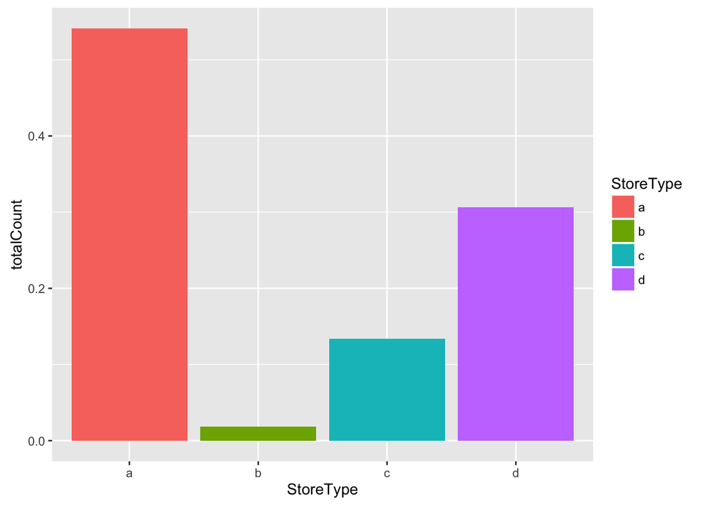

```r
# count
type_count <- train %>% group_by(StoreType) %>% summarise(totalCount = n()/nrow(train))
g <- ggplot(data= type_count, aes(x = StoreType, y = totalCount, fill = StoreType)) + geom_bar(stat = "identity")
plot(g)
```

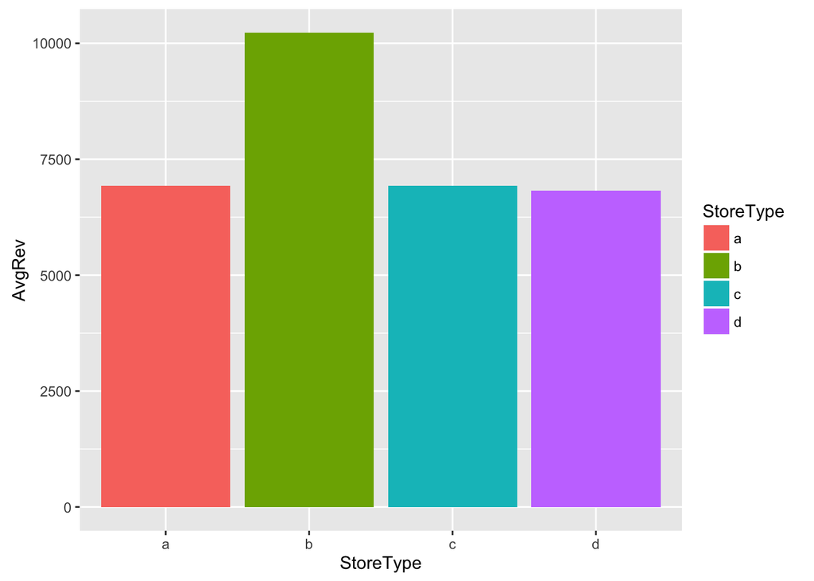

```r
type_Avg_sales <- train %>% group_by(StoreType) %>% summarise(AvgRev = as.numeric(sum(as.numeric(Sales)))/n())
g <- ggplot(data= type_Avg_sales, aes(x = StoreType, y = AvgRev, fill = StoreType)) + geom_bar(stat = "identity")
plot(g)
```

```r
rm(type_Avg_sales)
rm(type_count)
```

Clearly Storetype can be use a feature vector in the model

- **Assortment**: Distribution of Sales with Assortments

```r
head(train)
```

```
##   Store DayOfWeek       Date Sales Customers Open Promo StateHoliday
## 1     1         5 2015-07-31  5263       555    1     1            0
## 2     2         5 2015-07-31  6064       625    1     1            0
## 3     3         5 2015-07-31  8314       821    1     1            0
## 4     4         5 2015-07-31 13995      1498    1     1            0
## 5     5         5 2015-07-31  4822       559    1     1            0
## 6     6         5 2015-07-31  5651       589    1     1            0
##   SchoolHoliday months years StoreType Assortment CompetitionDistance
## 1             1    Jul  2015         c          a                1270
## 2             1    Jul  2015         a          a                 570
## 3             1    Jul  2015         a          a               14130
## 4             1    Jul  2015         c          c                 620
## 5             1    Jul  2015         a          a               29910
## 6             1    Jul  2015         a          a                 310
##   CompetitionOpenSinceMonth CompetitionOpenSinceYear Promo2
## 1                         9                     2008      0
## 2                        11                     2007      1
## 3                        12                     2006      1
## 4                         9                     2009      0
## 5                         4                     2015      0
## 6                        12                     2013      0
##   Promo2SinceWeek Promo2SinceYear   PromoInterval
## 1              NA              NA
## 2              13            2010 Jan,Apr,Jul,Oct
## 3              14            2011 Jan,Apr,Jul,Oct
## 4              NA              NA
## 5              NA              NA
## 6              NA              NA
```

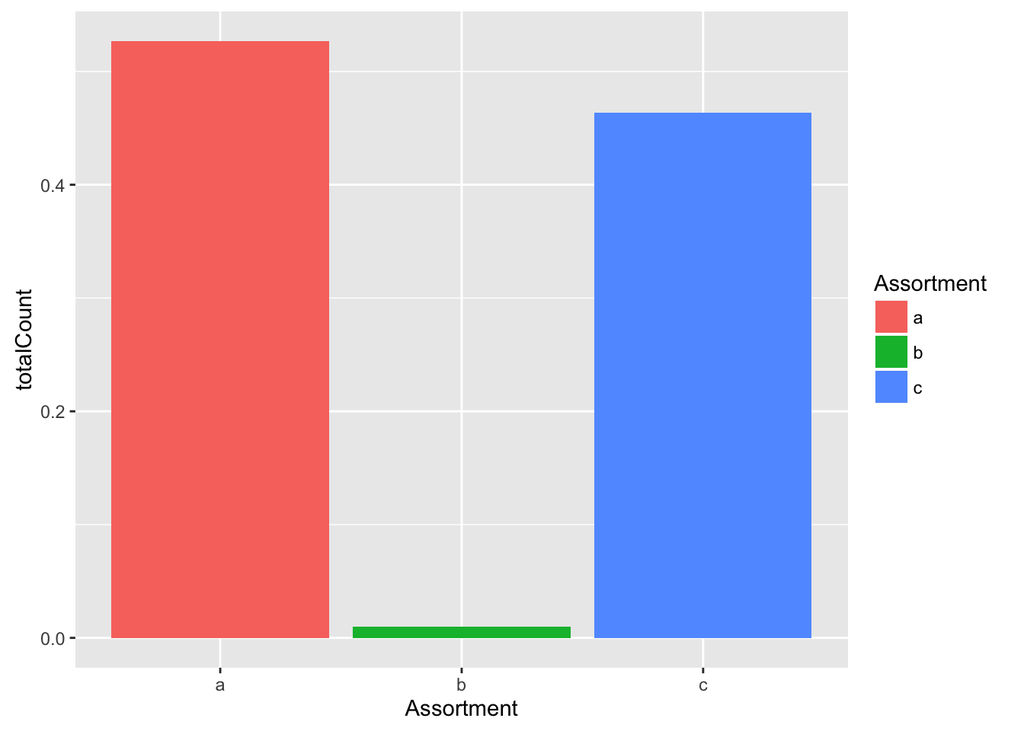

```r
# count
Assortment_count <- train %>% group_by(Assortment) %>% summarise(totalCount = n()/nrow(train))
g <- ggplot(data= Assortment_count, aes(x = Assortment, y = totalCount, fill = Assortment)) + geom_bar(stat = "identity")
plot(g)
```

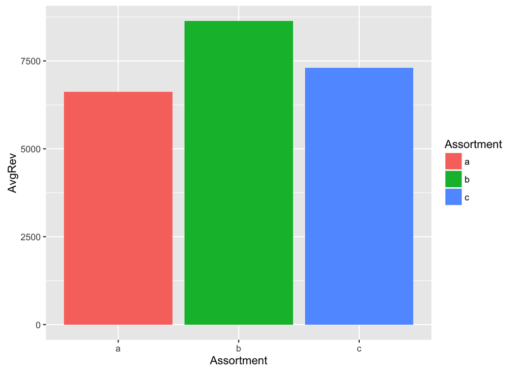

```r
Assortment_Avg_sales <- train %>% group_by(Assortment) %>% summarise(AvgRev = as.numeric(sum(as.numeric(Sales)))/n())
g <- ggplot(data= Assortment_Avg_sales, aes(x = Assortment, y = AvgRev, fill = Assortment)) + geom_bar(stat = "identity")
plot(g)
```

```r
rm(g)
rm(Assortment_count)
rm(Assortment_Avg_sales)
```

- **CompetitionDistance**: Let’s check the correlation of CompetitionDistance with Sales:

```r
# train$CompetitionDistance has 'NA' values, so if there is competiting shop near to a existing then obvious it effect the sales values to the existing shop and if the distance goes furhter then the effect of competiting open shop might be less on Sales, so it is inversly propersional to sales i.e train$CompetitionDistance increase then effect on sales values decreases. Now to handle the shop which has no completiting shop near by, it can be handle by putting large value of train$CompetitionDistance, i.e two times the max(train$CompetitionDistance).
maxValue <- 2*max(train$CompetitionDistance, na.rm = TRUE)
train[is.na(train$CompetitionDistance), ]$CompetitionDistance <- maxValue
cor(train$Sales, train$CompetitionDistance)
```

```
## [1] -0.04299887
```

Negative correlation show that the competition Distance has inversely proportional to Sales, so it can reverse and then find the correlation

```r
#Reverse the distance i.e 1/CompetitionDistance for each rows
```